# 基本繪圖 (Base Plotting System)

朱志泓

2017年2月17日

# **0. 玩具資料(Toy datasets)**

R語言內建即設有許多測試用的資料，常用以測試工具對資料之可用性，而這些內建資料稱為**玩具資料**。

## **0.1. 顯示內建資料集**

使用函數`data()`，可用以呼叫內建資料集(*紅色線條*部分之視窗)，*綠色範圍*為資料名稱，*藍色範圍*為資料內容概述。

```
data()
```

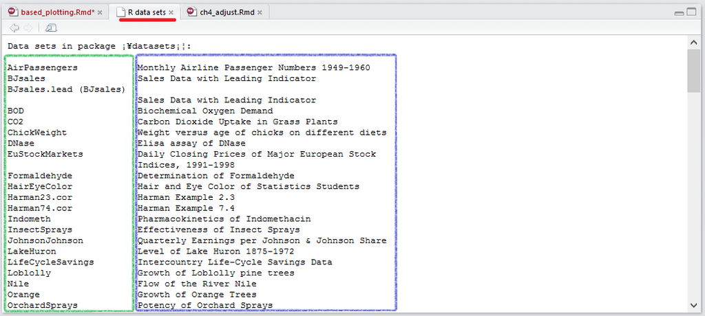

## **0.2. 觀察玩具資料(以iris為例)**

# 查詢資料說明

```
?iris
```

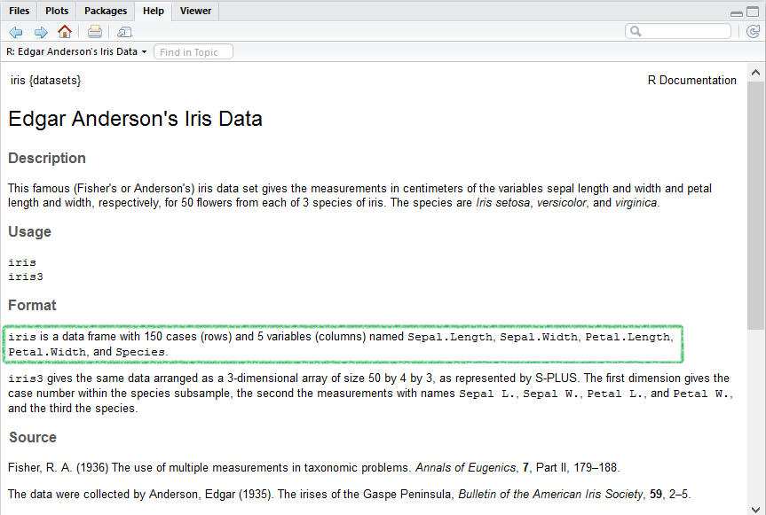

# 檢視資料內容

```
View(iris)
```

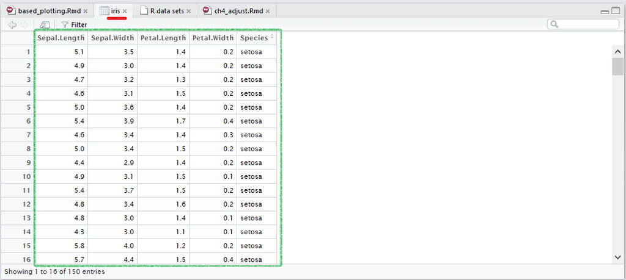

# 檢視資料結構

```r
str(iris)
```

```
## 'data.frame':    150 obs. of  5 variables:
##  $ Sepal.Length: num  5.1 4.9 4.7 4.6 5 5.4 4.6 5 4.4 4.9 ...
##  $ Sepal.Width : num  3.5 3 3.2 3.1 3.6 3.9 3.4 3.4 2.9 3.1 ...
##  $ Petal.Length: num  1.4 1.4 1.3 1.5 1.4 1.7 1.4 1.5 1.4 1.5 ...
##  $ Petal.Width : num  0.2 0.2 0.2 0.2 0.2 0.4 0.3 0.2 0.2 0.1 ...
##  $ Species     : Factor w/ 3 levels "setosa","versicolor",..: 1 1 1 1 1 1 1 1 1 1 ...
```

# 查詢資料敘述性統計

```r
summary(iris)
```

```
##   Sepal.Length    Sepal.Width     Petal.Length    Petal.Width
##  Min.   :4.300   Min.   :2.000   Min.   :1.000   Min.   :0.100
##  1st Qu.:5.100   1st Qu.:2.800   1st Qu.:1.600   1st Qu.:0.300
##  Median :5.800   Median :3.000   Median :4.350   Median :1.300
##  Mean   :5.843   Mean   :3.057   Mean   :3.758   Mean   :1.199
##  3rd Qu.:6.400   3rd Qu.:3.300   3rd Qu.:5.100   3rd Qu.:1.800
##  Max.   :7.900   Max.   :4.400   Max.   :6.900   Max.   :2.500
##        Species
##  setosa    :50
##  versicolor:50
##  virginica :50
##
##
##
```

# **1. 散佈圖(Scatter)**

玩具資料採用`cars`，觀察車速(speed)與煞車距離(dist)之關係。

# 觀察前幾筆資料

```r
head(cars)
```

```
##   speed dist
## 1     4    2
## 2     4   10
## 3     7    4
## 4     7   22
## 5     8   16
## 6     9   10
```

## **1.1. 畫散佈圖**

使用`plot`函數。

# main：圖片命名

# xlab：x軸標籤，預設為原資料欄位名稱

# ylab：y軸標籤，預設為原資料欄位名稱

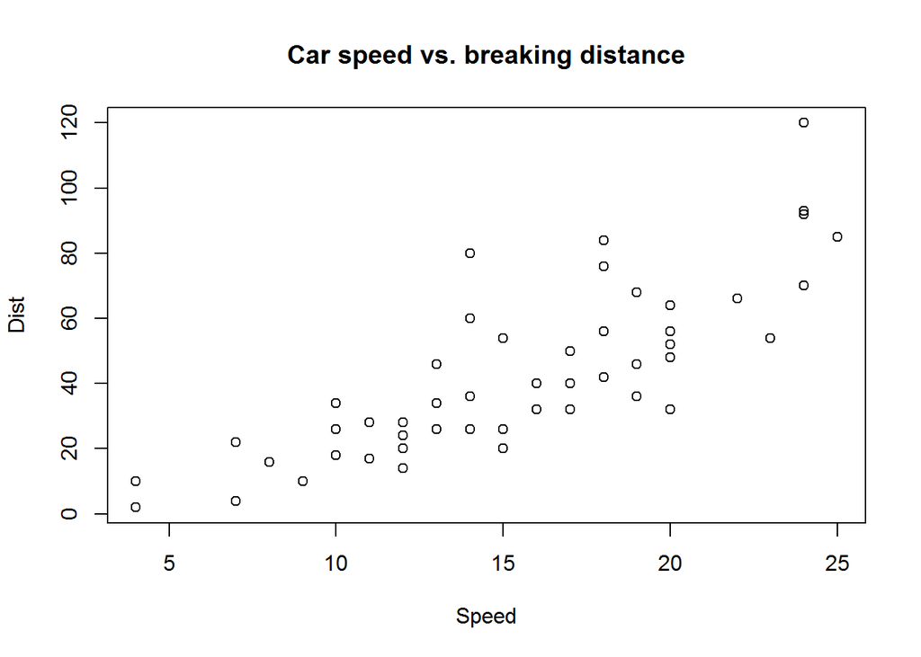

```r
plot(cars$speed, cars$dist, main = "Car speed vs. breaking distance", xlab = "Speed", ylab = "Dist")
```

# **2. 線圖(Line Graph)**

玩具資料採用`diamonds`，觀察鑽石長度(x)與闊度(y)之關係。

# 玩具資料`diamonds`儲存在套件`ggplot2`套件中，因此需先安裝並載入套件。

```r
library(ggplot2)
```

# 觀察前幾筆資料

```r
head(diamonds)
```

```
## # A tibble: 6 × 10
##   carat       cut color clarity depth table price     x     y     z
##   <dbl>     <ord> <ord>   <ord> <dbl> <dbl> <int> <dbl> <dbl> <dbl>
## 1  0.23     Ideal     E     SI2  61.5    55   326  3.95  3.98  2.43
## 2  0.21   Premium     E     SI1  59.8    61   326  3.89  3.84  2.31
## 3  0.23      Good     E     VS1  56.9    65   327  4.05  4.07  2.31
## 4  0.29   Premium     I     VS2  62.4    58   334  4.20  4.23  2.63
## 5  0.31      Good     J     SI2  63.3    58   335  4.34  4.35  2.75
## 6  0.24 Very Good     J    VVS2  62.8    57   336  3.94  3.96  2.48
```

為了簡化圖形之複雜度，採用玩具資料之前15筆作為畫圖數據。

```r
my_diamonds <- head(diamonds, n = 15L)
```

## **2.1. 畫線圖**

線圖(Line Graph)亦是使用`plot`函數，將其中參數type更改為“l”(lines)。

# type：圖形種類，預設為“p”(points)

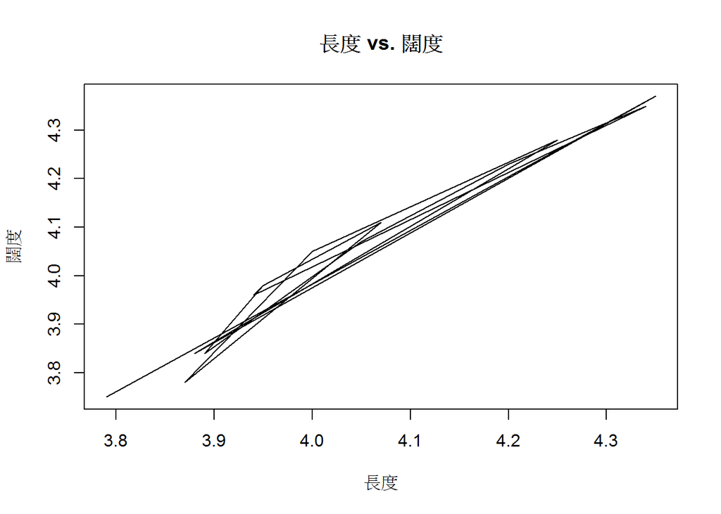

```r
plot(my_diamonds$x, my_diamonds$y, type = "l", main = "長度 vs. 闊度", xlab = "長度", ylab = "闊度")
```

圖形看起來不太對勁，原來畫線順序是即為資料排序，因此需讓資料做重排的動作，依x軸資料之大小排序。

```r
library(dplyr)
my_diamonds <- arrange(my_diamonds, x)
```

再畫一次。

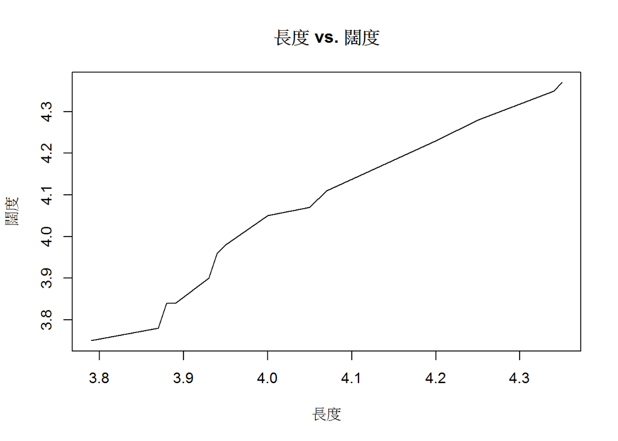

```r
plot(my_diamonds$x, my_diamonds$y, type = "l", main = "長度 vs. 闊度", xlab = "長度", ylab = "闊度")
```

## **2.2. 其他引數**

### **2.2.1. 修改圖案(type)**

如前所述，參數type預設為“p”(point)(分布圖)，也可設為“l”(line)(線圖)。

此外，亦可設為“b”(both)，代表同時包含點和線。

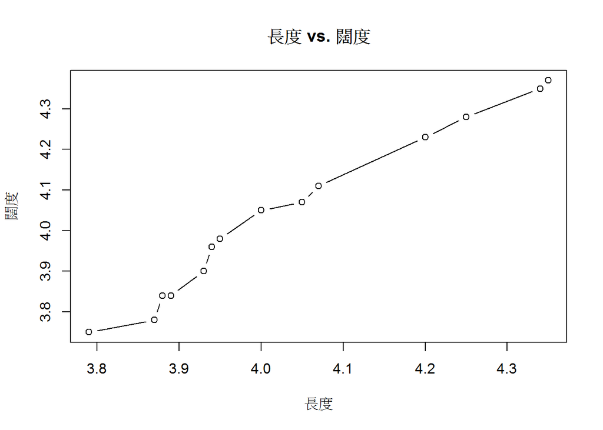

```r
plot(my_diamonds$x, my_diamonds$y, type = "b", main = "長度 vs. 闊度", xlab = "長度", ylab = "闊度")
```

### **2.2.2. 修改顏色(col)**

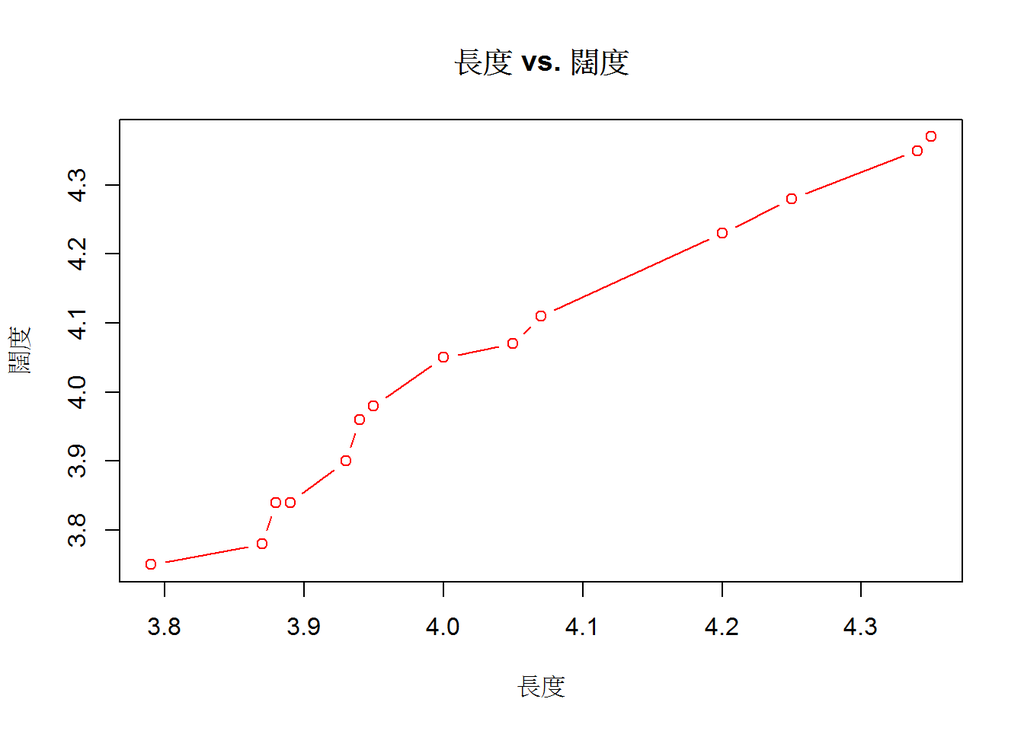

```r
plot(my_diamonds$x, my_diamonds$y, type = "b", main = "長度 vs. 闊度", xlab = "長度", ylab = "闊度", col = "red")
```

在plot函數下似乎無法分別修改點和線的顏色，在下一個單元**進階繪圖**將可使用套件`ggplot2`來完成。

### **2.2.3. 修改線的寬度(lwd)**

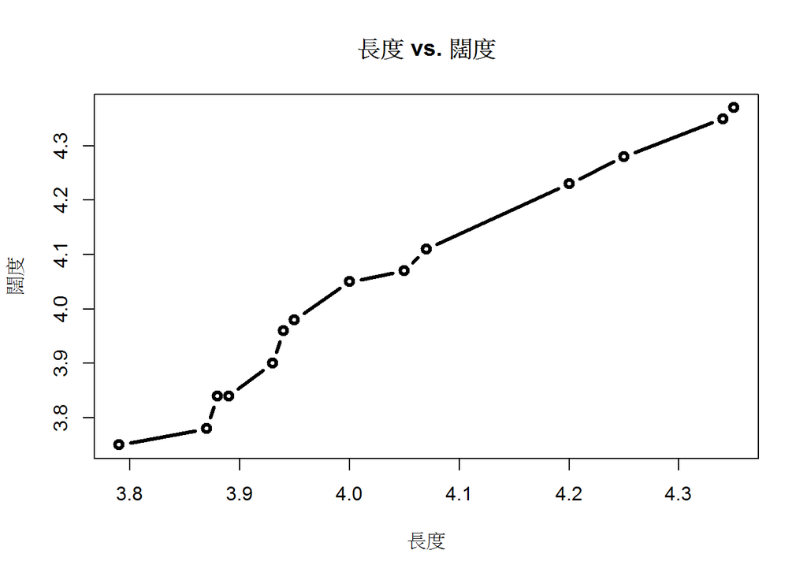

```r
plot(my_diamonds$x, my_diamonds$y, type = "b", main = "長度 vs. 闊度", xlab = "長度", ylab = "闊度", lwd = 3)
```

### **2.2.4. 修改點與線的樣式(pch與lty)**

# pch = 4：選擇叉叉 # lty = 2：選擇虛線

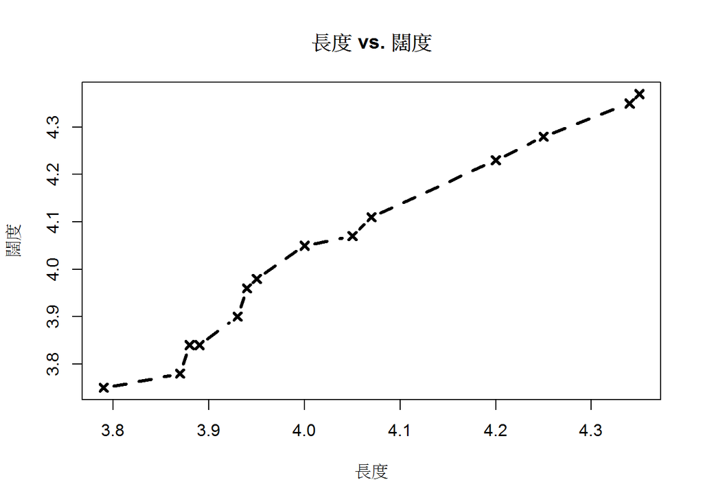

```r
plot(my_diamonds$x, my_diamonds$y, type = "b", main = "長度 vs. 闊度", xlab = "長度", ylab = "闊度", lwd = 3, pch = 4, lty = 2)
```

點與線的樣式選擇可從Help中搜尋。(`?plot`和`?par`)

# **3. 直方圖(Histogram)**

玩具資料採用`cars`，觀察車速(speed)之分布。

## **3.1. 畫直方圖**

使用`hist`函數

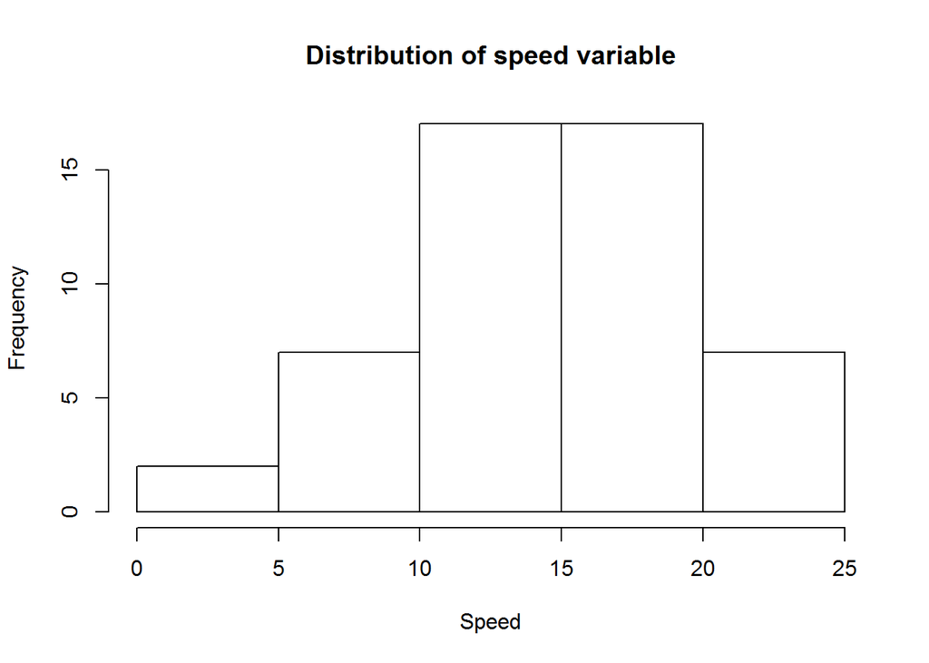

```r
hist(cars$speed, main = "Distribution of speed variable", xlab = "Speed")
```

## **3.2. 其他引數**

### **3.2.1 分箱(breaks)**

可用以控制直方寬度(直方數)。

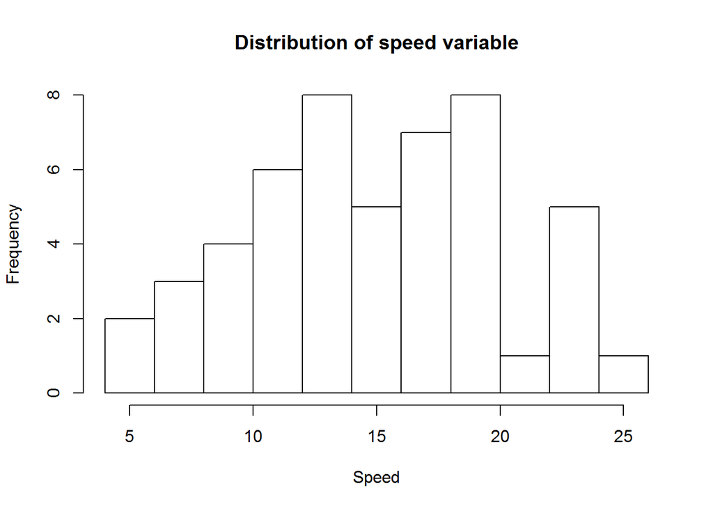

```r
hist(cars$speed, main = "Distribution of speed variable", xlab = "Speed", breaks = 8)
```

然而`hist`函數對於此`break`引數的功能似乎沒有設立很完善。

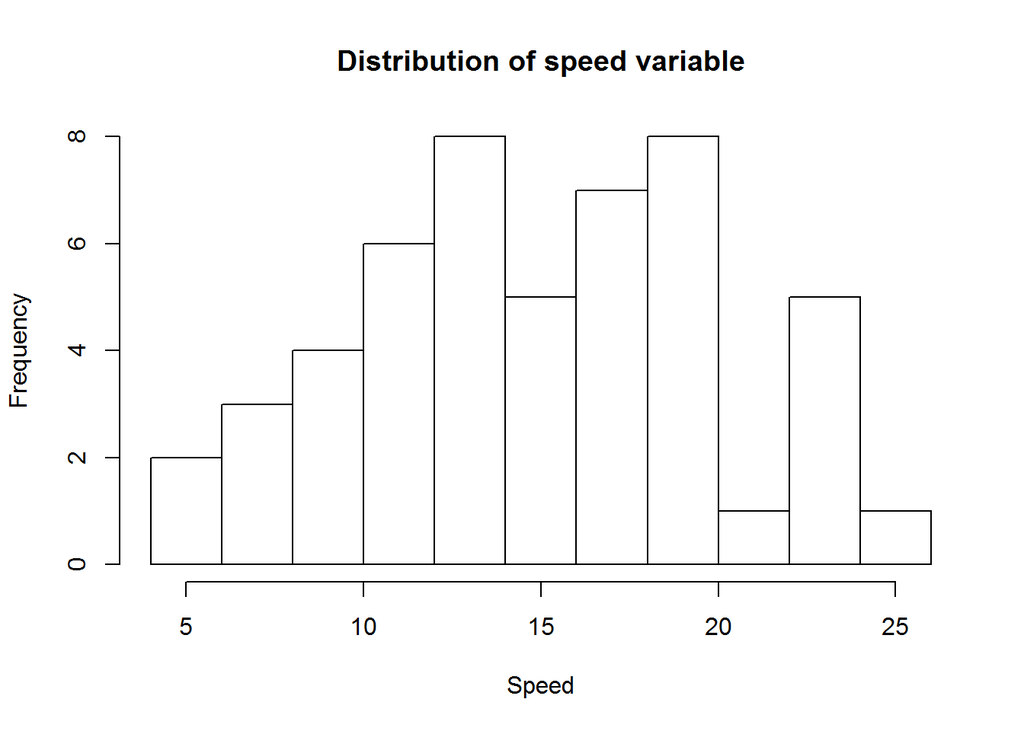

```r
hist(cars$speed, main = "Distribution of speed variable", xlab = "Speed", breaks = 12)
```

與設立`breaks = 8`相同。

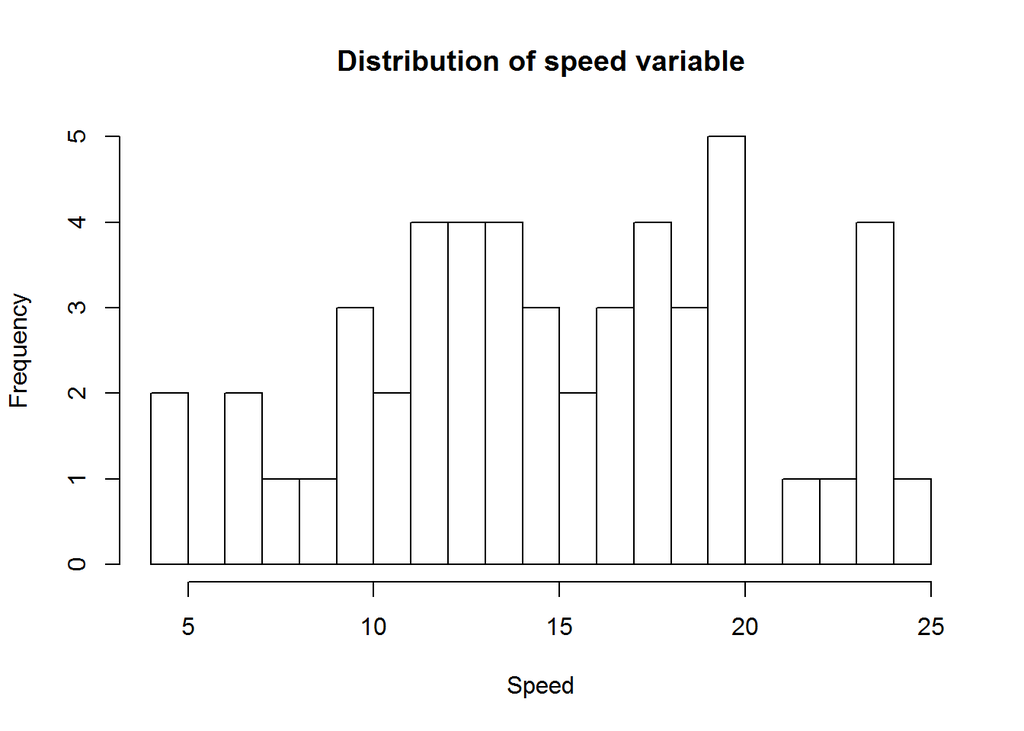

```r
hist(cars$speed, main = "Distribution of speed variable", xlab = "Speed", breaks = 16)
```

## **3.3. 網格畫布**

若想一次呈現多圖，可事先規劃規格及排列方式。

# 建立一個 1x2 且依照列排列的網格畫布(1列2欄)

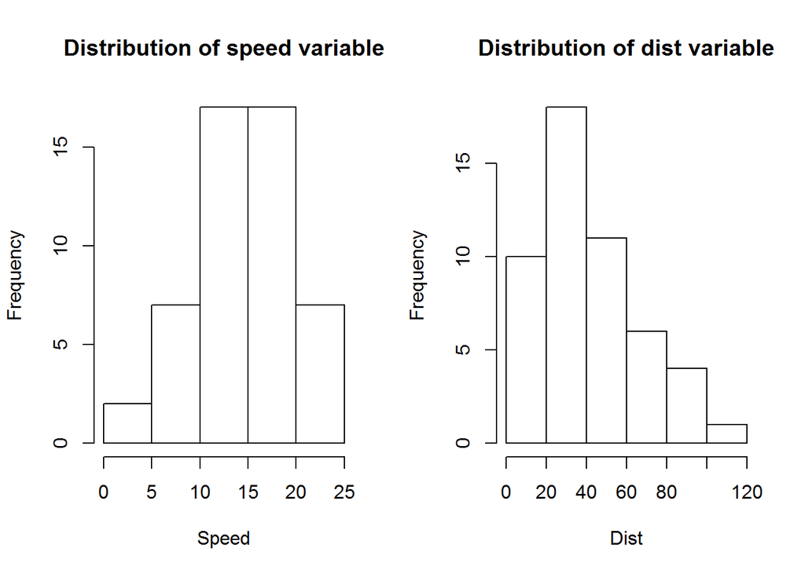

```r
par(mfrow = c(1, 2))
hist(cars$speed, main = "Distribution of speed variable", xlab = "Speed")
hist(cars$dist, main = "Distribution of dist variable", xlab = "Dist")
```

# 建立一個 2x1 且依照行排列的網格畫布(2列1欄)

# runif(n)：產生n個均勻分配之函數，預設範圍為0~1

# rnorm(n)：產生n個常態分配之函數，預設mean = 0、sd = 1

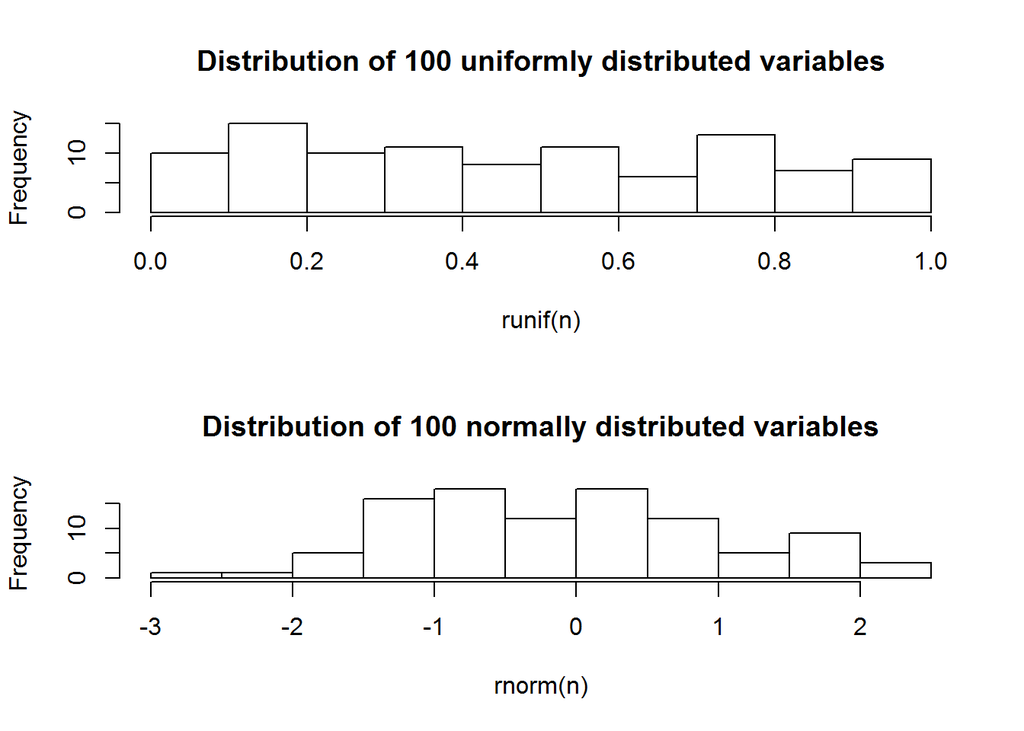

```r
par(mfcol = c(2, 1))
n <- 100
hist(runif(n), main = paste("Distribution of", n, "uniformly distributed variables")) # 試著增加隨機數的個數 n
hist(rnorm(n), main = paste("Distribution of", n, "normally distributed variables")) # 試著增加隨機數的個數 n
```

`paste`函數可用於印出變數所代表的值，區分字串和變數名稱。並且以空格作為區隔。

# **4. 盒鬚圖(Boxplot)**

玩具資料採用`iris`，分別觀察不同品種(Species)的花瓣(Petal)與萼片(Sepal)之長度(Length)與寬度(Width)之分布。

## **4.1. 畫盒鬚圖**

使用`boxplot`函數，直接畫萼片之長度分佈。

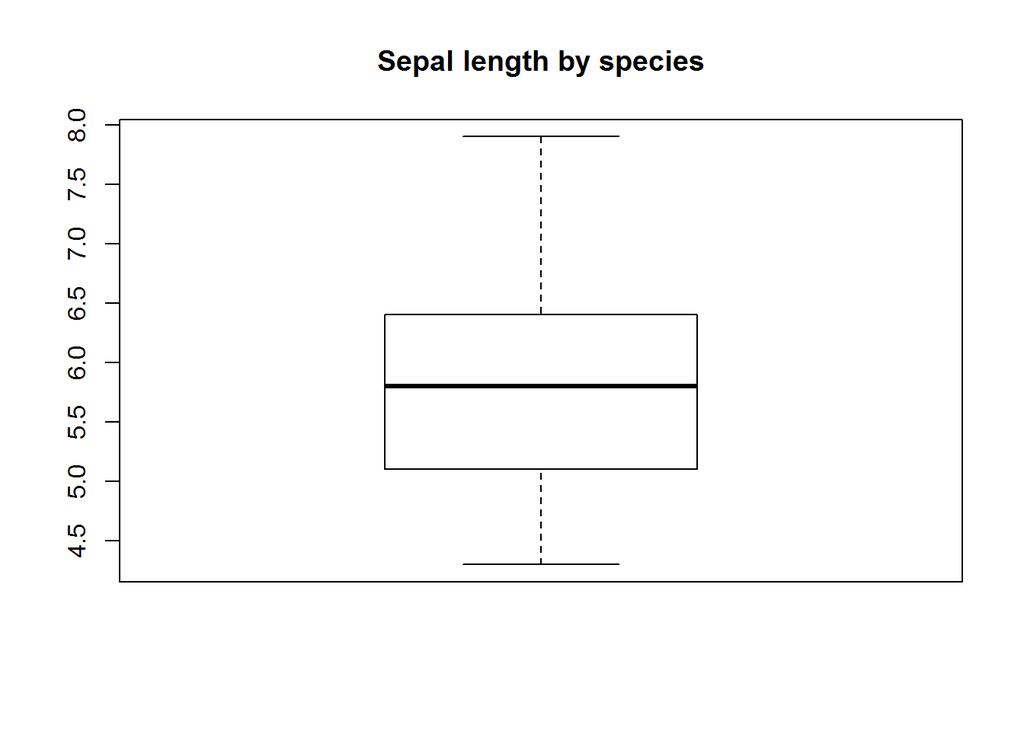

```r
boxplot(iris$Sepal.Length, main = "Sepal length by species")
```

使用`~`指定分別按品種(Species)畫盒鬚圖。

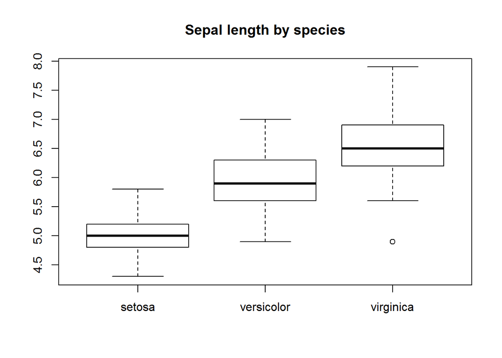

```r
boxplot(iris$Sepal.Length ~ iris$Species, main = "Sepal length by species")
```

依照不同品種(Species)的花瓣(Petal)與萼片(Sepal)之長度(Length)與寬度(Width)之分布。

# 按照*列*方向排序

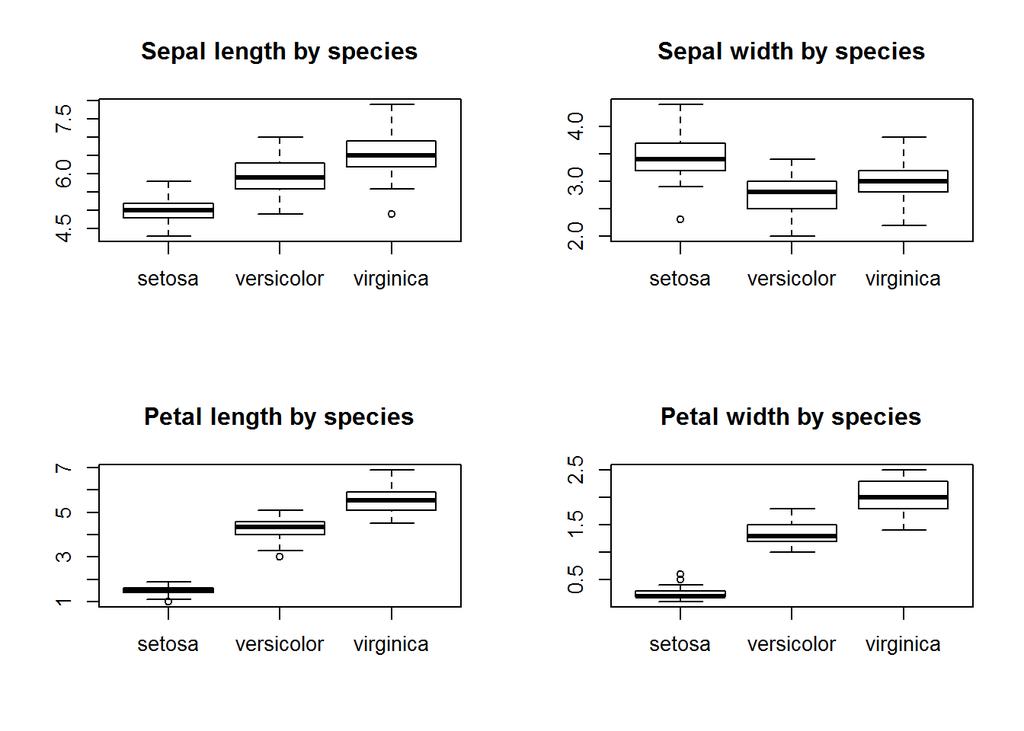

```r
par(mfrow = c(2, 2))
boxplot(iris$Sepal.Length ~ iris$Species, main = "Sepal length by species")
boxplot(iris$Sepal.Width ~ iris$Species, main = "Sepal width by species")
boxplot(iris$Petal.Length ~ iris$Species, main = "Petal length by species")
boxplot(iris$Petal.Width ~ iris$Species, main = "Petal width by species")
```

# 按照*行*方向排序

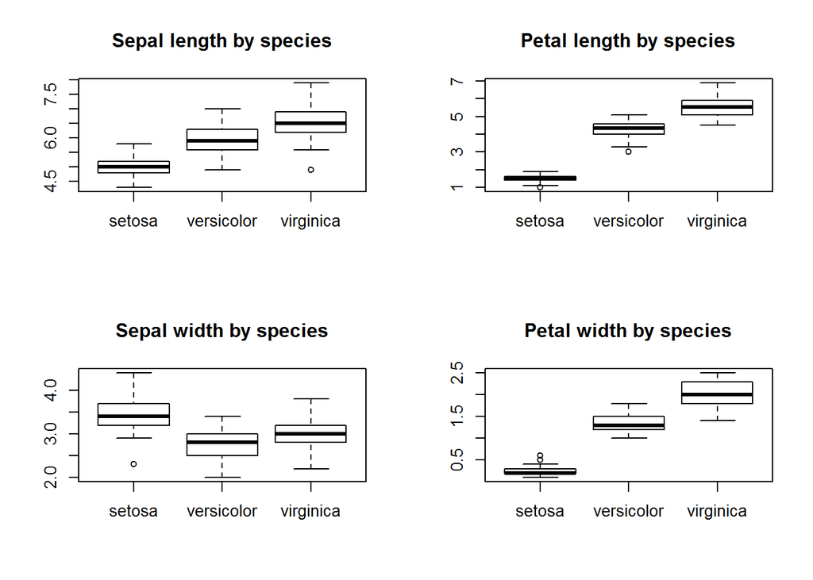

```r
par(mfcol = c(2, 2))
boxplot(iris$Sepal.Length ~ iris$Species, main = "Sepal length by species")
boxplot(iris$Sepal.Width ~ iris$Species, main = "Sepal width by species")
boxplot(iris$Petal.Length ~ iris$Species, main = "Petal length by species")
boxplot(iris$Petal.Width ~ iris$Species, main = "Petal width by species")
```

# **5. 長條圖(Bar chart)**

長條圖常用於計數(count)，類別不多時。而直方圖用於觀察分布。

玩具資料採用`mtcars`，為不同齒輪(gear)之車輛數作計數，以及列出每種車型的馬力(hp)。

## **5.1. 畫長條圖**

使用`barplot`函數

### **5.1.1. 計數**

未計數的悲劇

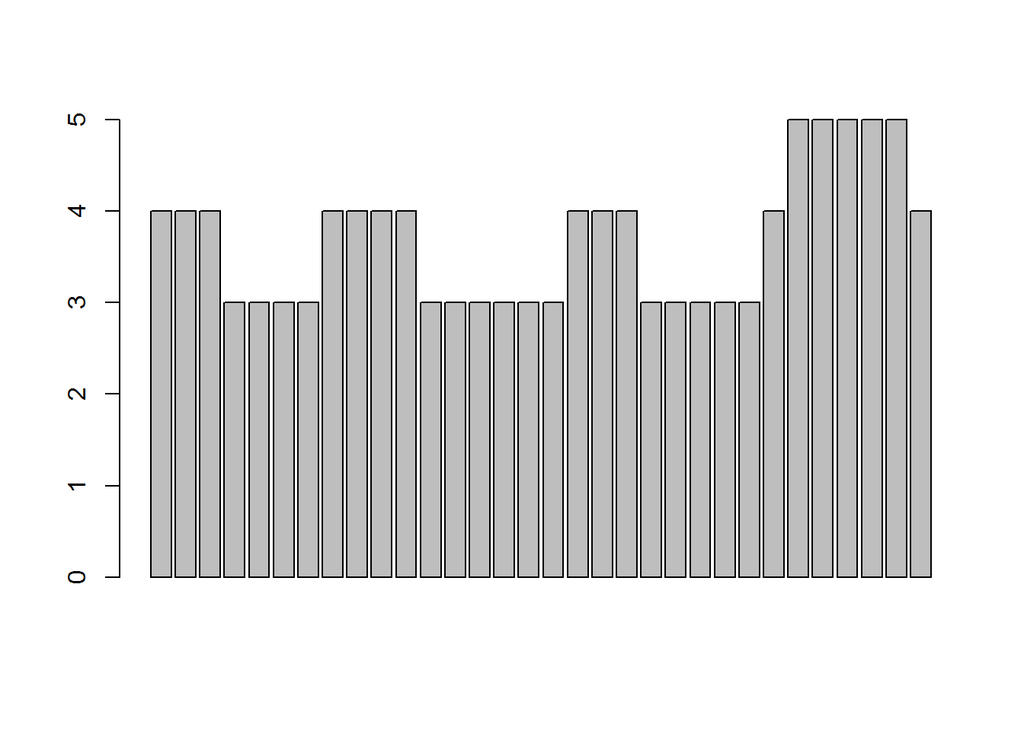

```r
barplot(mtcars$gear)
```

計數

```r
table(mtcars$gear)
```

```
##
##  3  4  5
## 15 12  5
```

### **5.1.2. 畫圖**

依照齒輪(gear)計數

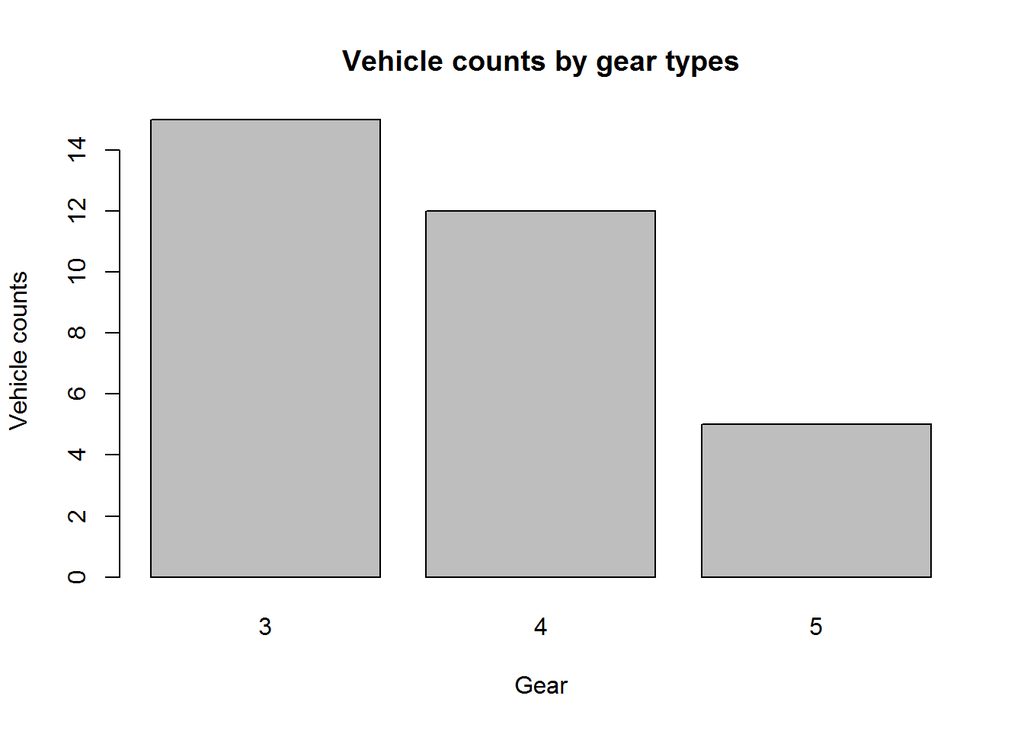

```r
barplot(table(mtcars$gear), main = "Vehicle counts by gear types", xlab = "Gear", ylab = "Vehicle counts")
```

## **5.2. 呈現長度**

列出每種車型的馬力(hp)

```r
vehicle_names <- row.names(mtcars)
```

若不指定名稱，僅按列的排序列出長條圖。

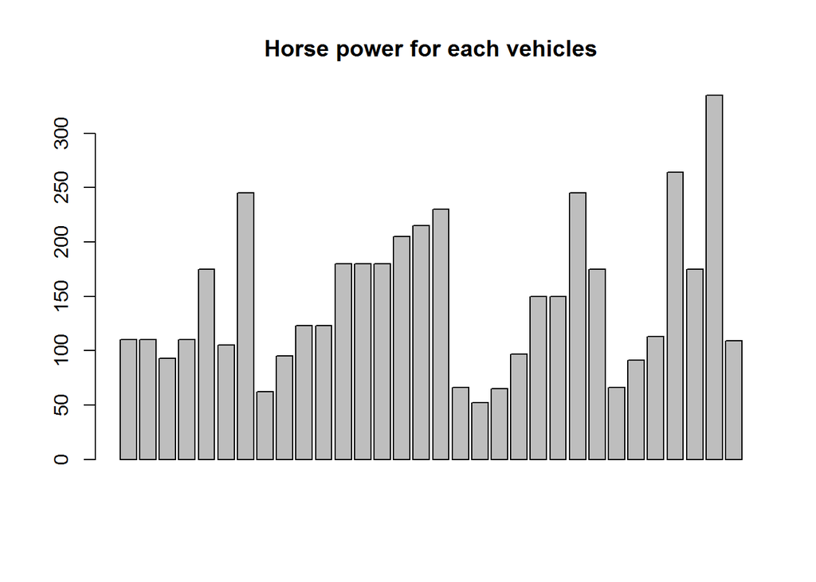

```r
barplot(mtcars$hp, main = "Horse power for each vehicles")
```

# names.arg：附上種類名稱

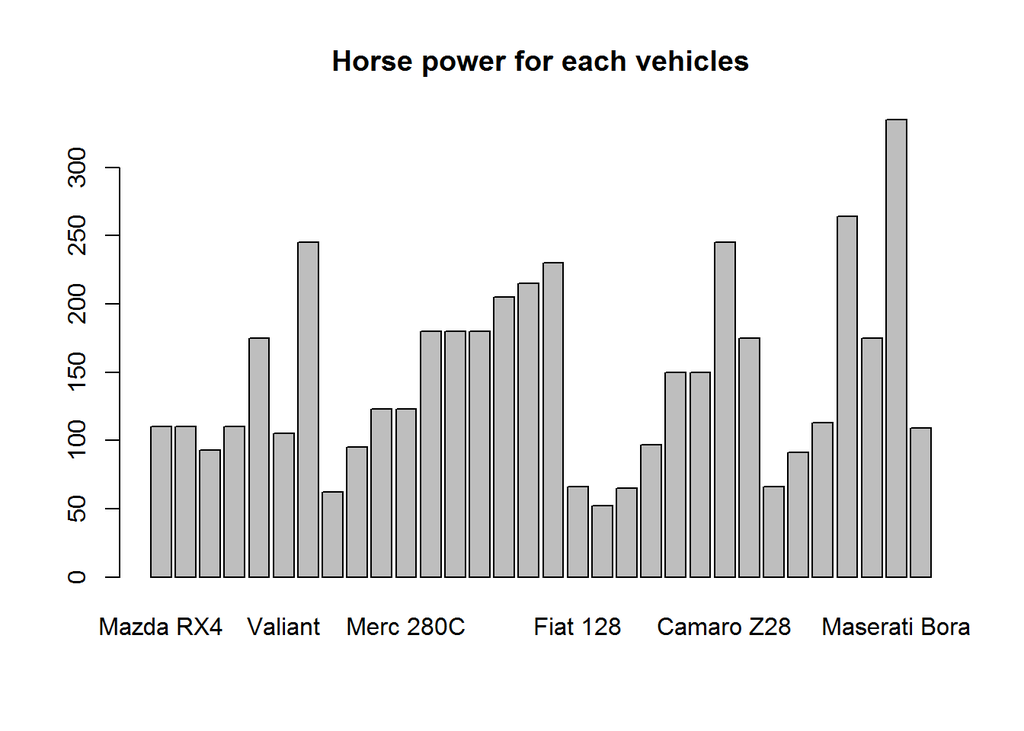

```r
barplot(mtcars$hp, names.arg = vehicle_names, main = "Horse power for each vehicles")
```

然而發現橫軸無法容納所有車型名稱，故將長條圖調整成水平。

# horiz：水平與否，預設為FALSE(垂直)，更改為TRUE(水平)

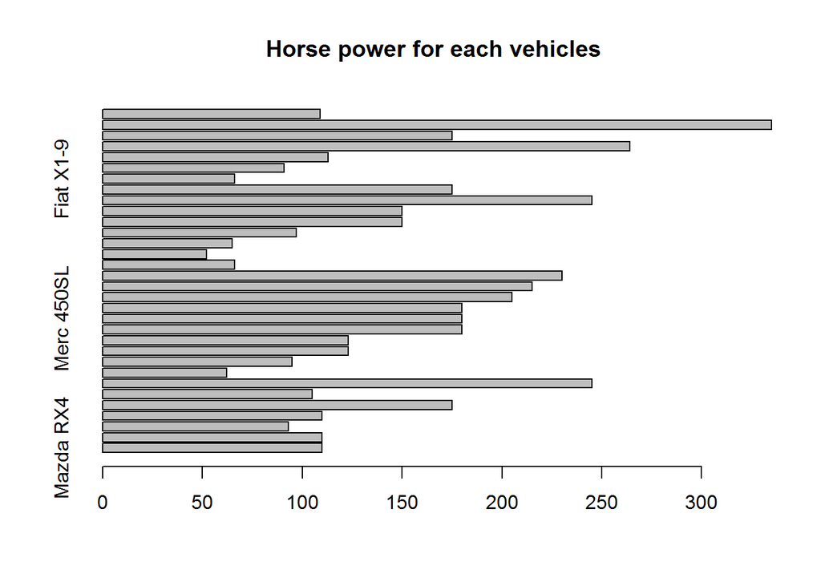

```r
barplot(mtcars$hp, names.arg = vehicle_names, main = "Horse power for each vehicles", horiz = TRUE)
```

修改文字方向

# las：預設為0(標籤文字與軸為平行)，調成1(固定為橫向)

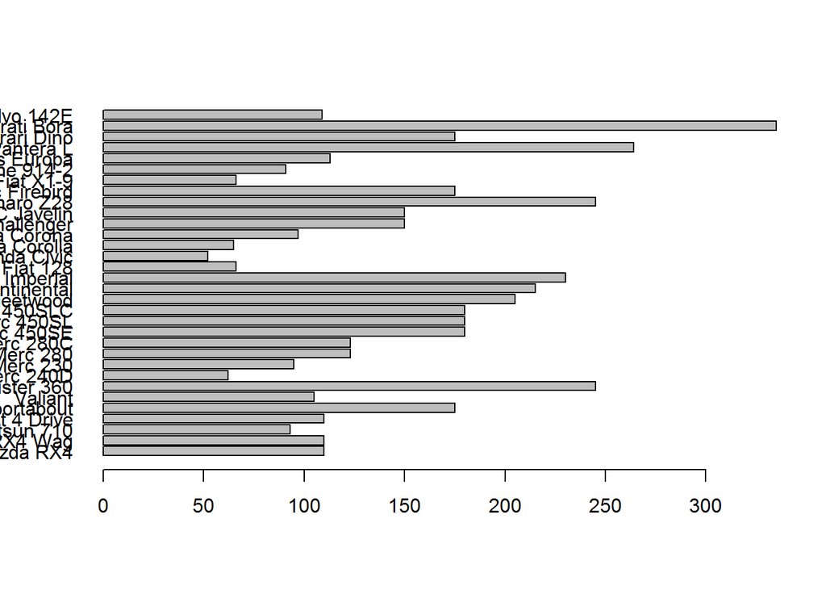

```r
barplot(mtcars$hp, names.arg = vehicle_names, horiz = TRUE, las = 1)
```

# cex.name：調整名稱文字大小

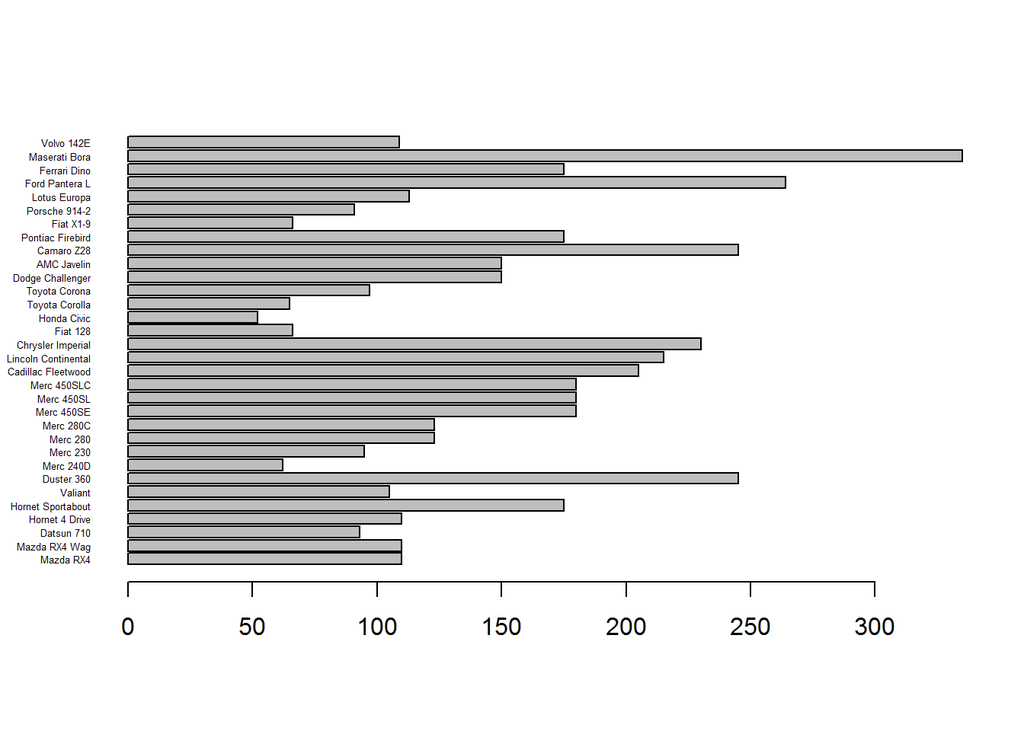

```r
barplot(mtcars$hp, names.arg = vehicle_names, horiz = TRUE, las = 1, cex.name = 0.4)
```

# cex.axis：調整數值文字大小

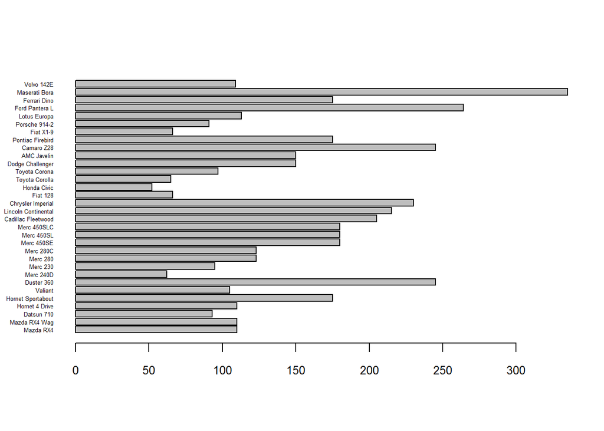

```r
barplot(mtcars$hp, names.arg = vehicle_names, horiz = TRUE, las = 1, cex.name = 0.4, cex.axis = 0.8)
```